# R Notebook

Strong patterns will hide subtler trends

It’s important to understand that a fitted model is just the closest model from a family of models. That implies that you have the “best” model (according to some criteria); it doesn’t imply that you have a good model and it certainly doesn’t imply that the model is “true”

```r
library(ggplot2)
library(dplyr)

library(modelr)
options(na.action = na.warn)
```

| x | y |
| --- | --- |
| 1 | 4.199913 |
| 1 | 7.510634 |
| 1 | 2.125473 |
| 2 | 8.988857 |
| 2 | 10.243105 |
| 2 | 11.296823 |

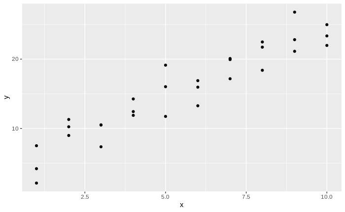

```r
ggplot(sim1, aes(x, y)) +
  geom_point()
```

You can see a strong pattern in the data. Let’s use a model to capture that pattern and make it explicit.

Let’s start by getting a feel for what models from that family look like by randomly generating a few and overlaying them on the data. For this simple case, we can use geom_abline() which takes a slope and intercept as parameters.

| a1 | a2 |
| --- | --- |
| -2.472974 | 4.057258 |
| 4.535986 | -2.369576 |
| 28.749228 | -4.377446 |
| 27.873315 | 2.461656 |
| -8.442622 | -3.032738 |
| -17.177955 | 3.698655 |

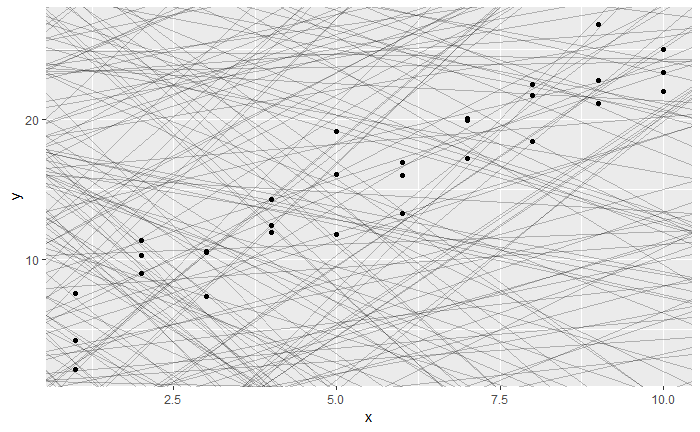

There are 250 models on this plot, but a lot are really bad! We need to find the good models by making precise our intuition that a good model is “close” to the data. We need a way to quantify the distance between the data and a model.

Then we can fit the model by finding the value of a_0 and a_1 that generate the model with the smallest distance from this data.

One easy place to start is to find the vertical distance between each point and the model

To compute this distance, we first turn our model family into an R function. This takes the model parameters and the data as inputs, and gives values predicted by the model as output:

```
 [1]  8.5  8.5  8.5 10.0 10.0 10.0 11.5 11.5 11.5 13.0 13.0 13.0 14.5 14.5 14.5 16.0 16.0 16.0 17.5
[20] 17.5 17.5 19.0 19.0 19.0 20.5 20.5 20.5 22.0 22.0 22.0
```

```
[1] 2.665212
```

Now we can use purrr to compute the distance for all the models defined above. We need a helper function because our distance function expects the model as a numeric vector of length 2.

[output not shown]

[output cut: 240 more lines]

Next, let’s overlay the 10 best models on to the data. I’ve coloured the models by -dist: this is an easy way to make sure that the best models (i.e. the ones with the smallest distance) get the brighest colours.

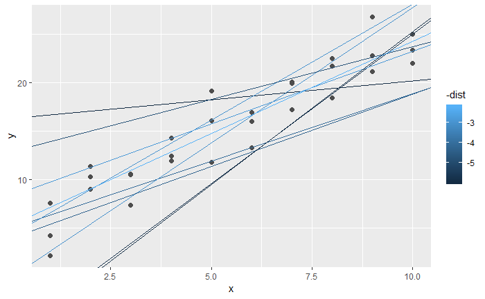